# Analysis of Single-Cell RNA-seq - Session 3

# GO term and pathway enrichment

We often want to carry out a *Gene Enrichment Analysis* on a list of genes of interest. This enables us to find *functional terms* that are statistically over-represented within a group of genes compared to a background list.

Seurat has in-built functionality to carry out a gene enrichment analysis using the `enrichr` package, which must be installed before carrying out this step.

`enrichr` allows users to check a list of genes, for example the ones found in a cluster, to gene set libraries of known biological function. For more information see https://maayanlab.cloud/Enrichr/#.

We can check for GO terms measuring BP (biological process), CC (cell component) and MF (molecular function).

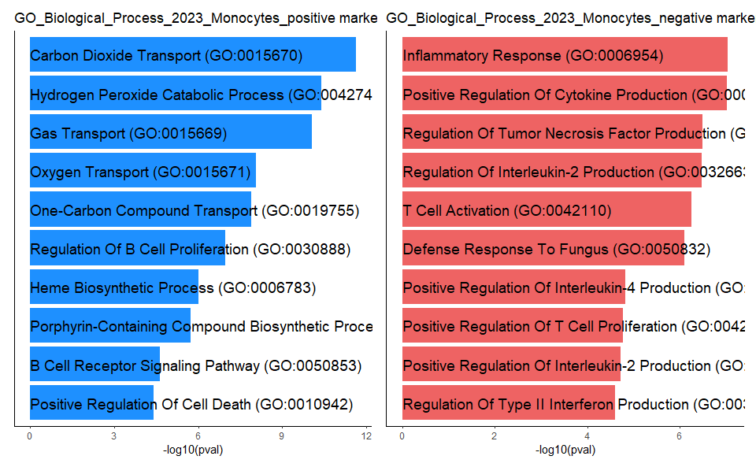

**Final Exercise!**

There are a number of different gene set libraries available in `enrichr` https://maayanlab.cloud/Enrichr/#libraries.

1. Have a look for over representation of functional terms in a different cluster of interest (for example Erythrocytes) and check against a different database

```r
# Put exercise work in here

results <- DEenrichRPlot(seurat, ident.1 = ....., enrich.database = ......, max.genes = 1000, num.pathway = 10)
```